# Hierarchical ordination

2023-08-20

# An Example of Hierarchical Ordination

This document describes fitting a hierarchical ordination to data, including code and the details that are needed.

The data is available on [figshare](https://doi.org/10.6084/m9.figshare.c.3297428.v1), but was originally collected by Ribera *et al.* (2001). It includes abundance observations of 68 ground beetles 87 sites in Scotland, along with 17 environmental variables and 20 traits. The aim to is determine how the environmental variables and traits affect composition in the ecological community, including whether they interact. The methodological question is how does hierarchical ordination help.

The abundances, traits and environment are each stored in a different matrix. First we load the data and set some constants:

```r
library(nimble)
library(nimbleHMC)
library(mvabund)
library(coda)
library(gllvm)

Y <- t(read.csv("/home/bertv/HierarchicalOrdinationOharar/Beetles/Y.csv"))
colnames(Y) <- Y[2,]
Y<-Y[-c(1:2),-c(1,70:71)]
Y <- as.data.frame(apply(Y,2,as.integer))
X <- read.csv("/home/bertv/HierarchicalOrdinationOharar/Beetles/X.csv")[,-c(1:5)]
X <- as.data.frame(apply(X,2,as.numeric))
X$Sampling.year <- X$Sampling.year - min(X$Sampling.year)
X$Texture <- as.factor(X$Texture)
TR  <- read.csv("/home/bertv/HierarchicalOrdinationOharar/Beetles/TR.csv")
row.names(TR) <- TR$SPECIES
TR <- TR[,-c(1:3)]
# Standardize data
X <- scale(model.matrix(~0+.,X)) # environmental variables
qrX <- qr(X)
X <- X[,qrX$pivot[1:qrX$rank],drop=F] # omit redundant predictors
TR <- scale(model.matrix(~0+.,TR)) # species traits
qrTR <- qr(TR)
TR <- TR[,qrTR$pivot[1:qrTR$rank],drop=F] # omit redundant traits

NSites <- nrow(Y) # number of sites
NSpecies <- ncol(Y) # number of species
NTraits <- ncol(TR) # number of traits
NEnv <- ncol(X) # number of environmental predictors

# create data lists for Nimble
dat <- list(Y = Y, X = as.matrix(X), TR = as.matrix(TR))
consts <- list(NSites = NSites, NEnv = NEnv, NTraits = NTraits, NSpecies = NSpecies)
```

## The Model

$$\eta_{ij} = \beta_{0j} + \boldsymbol{z}_i^\top \boldsymbol{\Sigma}
\boldsymbol{\gamma}_j.$$

As with any ordination, $\boldsymbol{z}$ and $\boldsymbol{\gamma}_j$ are the site scores and species loadings, and the columns of $\boldsymbol{Z}$ are the latent variables (which holds the site scores as the rows). Here we assume that they each have a variance of one, so that $\boldsymbol{\Sigma}$ holds the variation of the latent variables: it will typically be a diagonal matrix, and if any of the terms on the diagonal are close to zero, this suggests that latent variable has (almost) no effect. It thus provides a straightforward summary of the relative importance of that latent variable, and is similar to the square root of eigenvalues (singular values) in an eigenanalysis.

If we stopped here, this would be a standard Generalized Linear Latent Variable Model. But, here we want to model both $\boldsymbol{z}_i$ and $\boldsymbol{\gamma}_j$, i.e. go from modelling model groups of species responding in similar ways to sites to modelling how the traits of the species affect their responses to the environment.

As a simplification, we can think about this as simply a regression of $\boldsymbol{z}_i$ (the site effects) against the environmental variables and $\boldsymbol{\gamma}_j$ against the traits. In reality, it is more complicated, because $\boldsymbol{z}_i$ and $\boldsymbol{\gamma}_j$ are estimated in the model, so their uncertainty needs to be propagated.

**Some more mathematical details are hidden away here, for those who are interested.**

We denote the abundance at site $i = 1 \dots n$ for species $j = 1 \dots p$ as $Y_{ij}$, or as a matrix as $\boldsymbol{Y}$. The environmental variables are $x_{ik}$ for the $k = 1 \ldots K$ predictors (or $\boldsymbol{X}$ as a matrix), and $t = 1\ldots T$ traits as $\boldsymbol{TR}$. We then assume

with

$$\text{log}(\lambda_{ij}) =
\eta_{ij}.$$

Consequently, $\eta_{ij}$ is the linear predictor, which we further model with the hierarchical ordination:

$$\eta_{ij} = \beta_{0j} + \boldsymbol{z}_i^\top \boldsymbol{\Sigma}
\boldsymbol{\gamma}_j.$$

We then model $\boldsymbol{z}_i$ (as in [van der Veen *et al.* (2023)](https://besjournals.onlinelibrary.wiley.com/doi/full/10.1111/2041-210X.14035)) and $\boldsymbol{\gamma}_j$ hierarchically:

$$\boldsymbol{z}_i = \boldsymbol{B}^\top\boldsymbol{x}_i +
\boldsymbol{\epsilon}_i$$
and

$$\boldsymbol{\gamma}_j = \boldsymbol{\omega}^\top\boldsymbol{TR}_{j} +
\boldsymbol{\varepsilon}_j$$
where:

- $x_{ik}$ is the $k^{th}$ predictor (i.e. environmental effect) at site $i$
- $\boldsymbol{B}$ with entry $b_{kq} \sim \mathcal{N}(0,1)$ is the effect of the $k^{th}$ predictor on the site score for the $q^{th} = 1\ldots d$ latent variable
- $\boldsymbol{\epsilon}_i$ with entry $\epsilon_{iq} \sim \mathcal{N}(0, \sigma^2_q)$ is a vector of residuals for the unexplained part of the site score
- $TR_{jt}$ is the $t^{th}$ predictor (i.e. trait) for species $j$
- $\boldsymbol{\omega}_t$ with entry $\omega_{tq}$ is the effect of the $t^{th}$ trait on the species loading for the $q^{th}$ latent variable
- $\boldsymbol{\varepsilon}_j$ with entry $\varepsilon_{jq} \sim \mathcal{N}(0, \delta^2_q)$ is a vector of residuals for the unexplained part of the species loading

Note that the predictors are all standardized to zero mean and unit variance. We additionally place exponential priors with rate parameter one on all the scale parameters.

# Implementation

### One dimensional ordination

To fit the model we need to 1) code up the likelihood, 2) specify the Markov Chain Monte carlo samplers and initial values, 3) run it. We parallelise running the MCMC so that each chain is run on a different processor. This means we need a function to run one chain, and then another to run all of the chains together.

**The Nimble code for the model and likelihood is here**

```r
OneLV.nim <- nimbleCode({
  for (i in 1:NSites) {
    for (j in 1:NSpecies) {
# These three lines specify the model:
      Y[i, j] ~ dnegbin(phi[j]/(phi[j]+lambda[i, j]), phi[j]) # Likelihood: Y follows a NB distribution

      log(lambda[i, j]) <- eta[i, j] # Specify the log link function
      eta[i,j] <- beta0[j] + gamma[j]*sd.LV*z[i] # linear predictor: species + LV
    }
# Site scores: regression against environmental effects
#    the Bs are the coefficients of the environmental effects
      epsilonSTAR[i] ~ dnorm(0, sd = sd.Site) # Residual site effect
      XB[i] <- inprod(X[i, 1:NEnv],BSTAR[1:NEnv])
      zSTAR[i] <- XB[i] + epsilonSTAR[i]
  }

  for(j in 1:NSpecies) {
# Species effects: regression against trait effects
#    The Os are the trait effects.
      varepsilonSTAR[j] ~ dnorm(0, sd = sd.Species) # Residual
      omegaTR[j] <- inprod(TR[j, 1:NTraits],OSTAR[1:NTraits])
      gammaSTAR[j] <- omegaTR[j] + varepsilonSTAR[j]
      beta0[j] ~ dnorm(0, sd = 1) # Species means
  }

# Here we standardise z and gamma, so the both have a variance of 1.
#   The standard deviation of the latent variable is sd.LV.
    zmu <- mean(zSTAR[1:NSites])
    gammamu<- mean(gammaSTAR[1:NSpecies])
    StdDev.z <- sqrt(mean((zSTAR[1:NSites] - zmu)^2))
    StdDev.gamma <- sqrt(mean((gammaSTAR[1:NSpecies] - gammamu)^2))
    z[1:NSites] <- zSTAR[1:NSites]/StdDev.z
    gamma[1:NSpecies] <- gammaSTAR[1:NSpecies]/StdDev.gamma

# Scale other parameters
    epsilon[1:NSites] <- epsilonSTAR[1:NSites]/StdDev.z
    B[1:NEnv] <-  BSTAR[1:NEnv]/StdDev.z
    varepsilon[1:NSpecies] <- varepsilonSTAR[1:NSpecies]/StdDev.gamma
    O[1:NTraits] <-  OSTAR[1:NTraits]/StdDev.gamma

    # priors for scales
    sd.Site ~ dexp(1)
    sd.Species ~ dexp(1)
    sd.LV ~ dexp(1)

    for(k in 1:NEnv){
      BSTAR[k] ~ dnorm(0, sd = 1)
    }
    for(tr in 1:NTraits){
      OSTAR[tr] ~ dnorm(0, sd = 1)
    }
     for(j in 1:NSpecies){
      phi[j] ~ dexp(1)
    }
})
```

**Code to generate initial values is here**

```r
inits <- function(consts){
  B = rnorm(consts$NEnv)
  O = rnorm(consts$NTraits)
  varepsilon = rnorm(consts$NSpecies)
  epsilon = rnorm(consts$NSites)
  list(
    BSTAR = B,
    OSTAR = O,
    epsilonSTAR = epsilon,
    varepsilonSTAR = varepsilon,
    sd.Site = rexp(1),
    sd.Species = rexp(1),
    beta0 = rnorm(consts$NSpecies),
    sd.LV = rexp(1),
    phi = rexp(consts$NSpecies)
  )
}
```

**Functions for MCMC are here.**

```r
RunOneChain <- function(seed, dat, code, inits, consts, ToMonitor=NULL,
                        Nburn=5e3, NIter=5.5e4, Nthin=10, block = NULL, RW = NULL, ...) {
  require(nimble)
  require(nimbleHMC)
  AllSamplers <- HMCsamplers <- c('epsilonSTAR', 'varepsilonSTAR', 'beta0', 'OSTAR', 'BSTAR',
                  'sd.Site', 'sd.Species', 'sd.LV','phi')

  if(!is.null(block)){
  HMCsamplers <- HMCsamplers[!HMCsamplers%in%unique(gsub("\\s*\\[[^\\)]+\\]","",c(unlist(block),unlist(RW))))]
  }
  if(is.null(ToMonitor)) {
    ToMonitor <- c("beta0", "sd.Species", "sd.Site", "sd.LV", "B", "O",
                   "epsilon", "varepsilon", "gamma", "z", "phi")
  }
  mod <- nimbleModel(code = code, name = "HO", constants = consts,
                     inits = inits(consts), data = dat, buildDerivs = TRUE)
  model <- compileNimble(mod)

  # Do HMC
    conf <- configureHMC(model, nodes = HMCsamplers, monitors = ToMonitor, print = FALSE,
                         control=list(nwarmup=Nburn, kappa = 0.95, maxTreeDepth = 30))
    if(!is.null(block)) {
    if(is.list(block)){
    # Use a slice everything that not being HMCed
      lapply(block, conf$addSampler, type = "AF_slice", sliceAdaptFactorInterval = Nburn)
    }else{
      # Use a slice everything that not being HMCed
      sapply(block, conf$addSampler, type = "AF_slice", sliceAdaptFactorInterval = Nburn)
    }
    }

    if(!is.null(RW)) {
    if(is.list(RW)){
    # Use a slice everything that not being HMCed
      lapply(RW, conf$addSampler, type = "RW")
    }else{
      # Use a slice everything that not being HMCed
      sapply(RW, conf$addSampler, type = "RW")
    }
    }

  mcmc <- buildMCMC(conf)
  cmcmc <- compileNimble(mcmc, project = model)
  res <- runMCMC(cmcmc,  niter=NIter, nburnin = Nburn, thin=Nthin,
                 nchains = 1, samplesAsCodaMCMC = TRUE, ...)
  return(res)
}

# Function to run parallel chains
ParaNimble <- function(NChains, ...) {
  opts <- list(...)
  if(!is.null(opts$seeds) && (length(opts$seeds) == NChains)){
    seeds <- opts$seeds
    opts <- opts[-which(names(opts)=="seeds")]
  }else{
    seeds <- 1:NChains
  }
  require(parallel)
  nimble_cluster <- makeCluster(NChains)

  samples <- parLapply(cl = nimble_cluster, X = seeds, ...)
  stopCluster(nimble_cluster)

  # Name the chains in the list
  chains <- setNames(samples,paste0("chain", 1:length(samples)))
  chains
}

# Function to create list of names for parameters to use a block slice sampler for
MakeBlockList <- function(consts, LVwise = TRUE){
# builds list for slice AF sampling
# with LVwise = TRUE we are LV-wise blocking B and epsilon, and O and varepsilon
# otherwise, LVs are jointly blocked
if(LVwise & consts$nLVs>1){
blockList <- c(sapply(1:consts$nLVs,
       function(x,consts){
         c(paste0("BSTAR[", 1:consts$NEnv,", ",x, "]"),
           paste0("epsilonSTAR[", 1:consts$NSites,", ",x, "]"))
         }
       ,
         consts = consts,simplify=F),
       sapply(1:consts$nLVs,
       function(x,consts){
         c(paste0("OSTAR[", 1:consts$NTraits,", ",x, "]"),
           paste0("varepsilonSTAR[", 1:consts$NSpecies,", ",x, "]"))
         }
       ,
         consts = consts,simplify=F)
       )
if(consts$nLVs>1){
# remove entries of BSTAR that are fixed
for(q in 2:consts$nLVs){
  blockList[[q]] <- blockList[[q]][-(1:(q-1))]
}
}
}else{
  blockList = list(c("BSTAR","epsilonSTAR"),c("OSTAR","varepsilonSTAR"))
}
blockList
}
```

Latent variable models are notorious for being unidentifiable, you can get the same mean abundances from different combinations of the parameters. We have to make some adjustments to the model to account for this: some of this is done in the model fitting, but for others it is easier to do it after we obtain the posterior samples.

**The details of what we do to make the HO identifiable are here**

- First, we standardise $\boldsymbol{z}_i$ and $\boldsymbol{\gamma}_j$ to unit variance per latent variable to prevent scale invariance
- At this point the model is still invariant to sign switching: because $z_{i}\gamma_{j} = (-z_{i})(-\gamma_{j})$ in the MCMC algorithm can (and does) switch signs mid run. We could solve it by placing a truncated normal prior on the main diagonal entries of $\boldsymbol{B}$ or $\boldsymbol{\omega}$, but that results in bimodal posterior distributions for other coefficients. Instead we impose sign constraints by post-process the chains. We choose one parameter, for example one $z_{i}$ or $\gamma_{j}$, to be positive, and switch all of the other parameters based on that one. See below for the details of how we fix the signs.

The functions to swap the signs are included below. We want to make one parameter positive, so ideally we want to do this to a parameter that has both modes away from zero. We can identify this in an **ad hoc** way: for each chain for every parameter we calculate the proportion of iterations where the sign is positive, and then for every parameter we calculate the variance in that proportion. If a parameter is centered around 0 the mean proportion will be about 0.5, and will not vary much, whereas if it is some way from 0 the mean will be close to 0 or 1, and the variance will be high. ALternativley, we coiuld look at the largest $|p - 0.5|$, or we can vissually identify such parameters from the posterior samples. There may be even better alternatives.

```r
# Utility Function to get logical indicators for if names contains a string in v
GetInds <- function(v, names) {
  if(length(v)==1) {
    res <- grep(v, names)
  } else {
    res <- c(unlist(sapply(v, grep, x=names)))
  }
  res
}

# Function to swap signs of all variables varinds to have same sign as vartosign.
ReSignChain <- function(chain, varinds, vartosign) {
  #    MeanSign <- sign(mean(chain[  ,s])) # Might need this
  res <- t(apply(chain, 1, function(x, vs, vi) {
    Names <- names(x)[vi]
    if(any(grepl(",", Names))) {
      lvind <- gsub(".*, ", "", Names)
    } else {
      lvind <- seq_along(vs)
    }
    x[vi] <- x[vi]*sign(x[vs[lvind]])
    x
  }, vs=vartosign, vi=varinds))
  as.mcmc(res)
}



# Function to post-process chains to swap signs.
postProcess <- function(Chains, VarsToProcess, VarsToSwapBy = NULL, VarToSign=NULL, print=FALSE) {
  if(is.null(VarToSign)) VarToSign <- VarsToProcess
  SignInd <- GetInds(VarToSign, colnames(Chains[[1]]))
  # Get indicators for all variables to have their signs changed
  ProcessInds <- GetInds(VarsToProcess, names = colnames(Chains[[1]]))

  # Check if > 1 LV
  SeveralLVs <- any(grepl(",", colnames(Chains[[1]])[SignInd]))

  # Calculate variance of mean of indicator of sign:
  #    hopefully largest is variable with most sign swapping (i.e. )
  Signs <- as.data.frame(lapply(Chains, function(mat, ind) {
    colMeans(mat[,ind]>0)
  }, ind=SignInd))
    VarSign <- apply(Signs, 1, var)

  if(SeveralLVs) {
    LV <- gsub(".*, ", "", colnames(Chains[[1]])[SignInd])
    #Chose variables who's sign will be used to swap other signs
    if(is.null(VarsToSwapBy)){
      VarsToSwapBy <- sapply(unique(LV), function(lv, vs) {
      vv <- vs[grep(lv, names(vs))]
      nm <- names(which(vv==max(vv)))
      if(length(nm)>1) nm <- nm[1] # probably something more sophisticated is better
      nm
    }, vs = VarSign, simplify = TRUE)
    }
    if(print) message(paste0("Swapping by ", paste(VarsToSwapBy, collapse=", ")))
    chains.sgn <- lapply(Chains, ReSignChain, vartosign=VarsToSwapBy, varinds=ProcessInds)

  } else { # only 1 LV
    if(is.null(VarsToSwapBy)){
    #Chose variables who's sign will be used to swap other signs
    VarsToSwapBy <- names(which(VarSign==max(VarSign)))[1]
    }
    if(print) message(paste0("Swapping by ", paste(VarsToSwapBy, collapse=", ")))
#    chains.sgn <- lapply(Chains, ReSignChain, varNames=VarsToProcess, sign.var=ind)
    chains.sgn <- lapply(Chains, ReSignChain, vartosign=VarsToSwapBy, varinds=ProcessInds)
  }
  as.mcmc.list(chains.sgn)
}
```

Finally, we can run the MCMC.

```r
consts$nLVs = 1
chains.unsgn <- ParaNimble(4, fun = RunOneChain,
                       dat = dat,
                       code = OneLV.nim,
                       inits = inits,
#                       Nburn = 5e1, NIter = 5.5e2, Nthin = 1, # for a small run
                       Nburn = 1e3, NIter = 2e3, Nthin = 1, # for a big HMC run
                       consts = consts,
                       block = MakeBlockList(consts, LVwise = TRUE), RW = c(paste0("beta0[",1:consts$NSpecies,"]"),paste0("phi[",1:consts$NSpecies,"]"))) # HMC on the rest (hypers)

# post-process chains for sign-swapping
VarsToProcess <- c("^B", "^O", "^epsilon", "^varepsilon", "^z", "^gamma")
VarsToSign <- c("^B")
chains <- postProcess(chains.unsgn, VarsToProcess = VarsToProcess,
                      VarToSign = VarsToSign, print = TRUE, VarsToSwapBy = "B[26]")
summ.HO = summary(chains)
```

### Results

There are a lot of parameters, so a lot of results to look at. Here we concentrate on $\boldsymbol{B}$, $\boldsymbol{\omega}$, $\boldsymbol{\sigma}$ and $\boldsymbol{\delta}$, and a latent variable-plot.

**We can look at the chains, to see that they have converged.**

First the environmental effects:

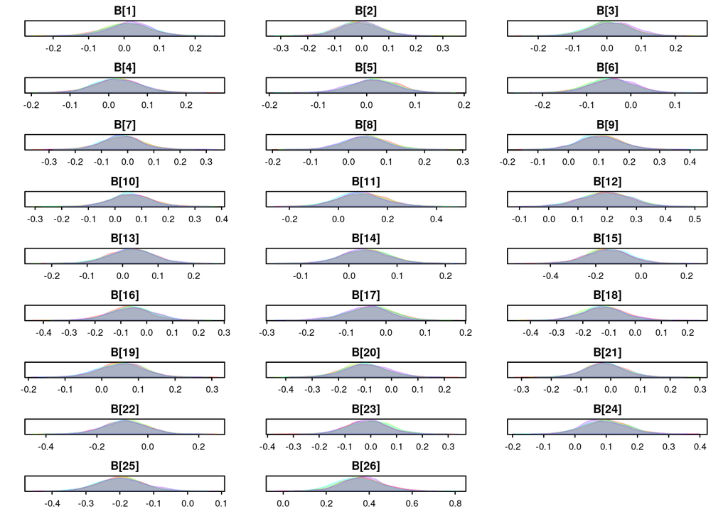

```r
library(basicMCMCplots)
chainsPlot(chains, var = c("B"), legend = F,traceplot = F, densityplot = T)
```

Then the trait effects:

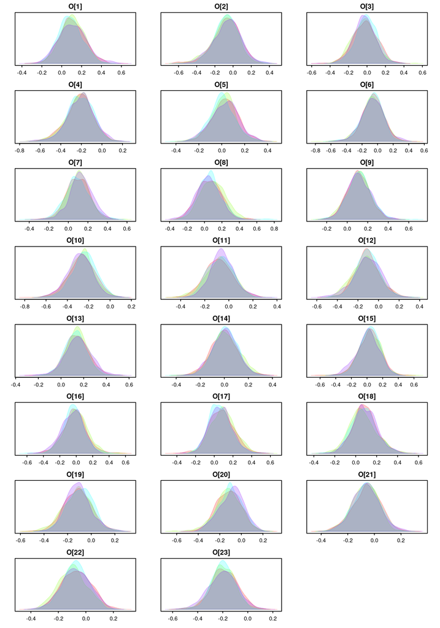

```r
chainsPlot(chains, var = c("O"), legend = F,traceplot = F)
```

**We use a plotting function, which is hidden here**

```r
PlotPost <- function(var, summ, varnames=NULL, ...) {
  vars <- grep(var, rownames(summ$statistics))
  if(is.null(varnames)) varnames <- rownames(summ$statistics)[grep(var, rownames(summ$statistics))]
  if(length(varnames)!=length(vars))
    stop(paste0("Number of variable names, ", length(varnames), "not the same as number of variables, ",
                length(vars)))

  plot(summ$statistics[vars,"Mean"], 1:length(vars),
       xlim=range(summ$quantiles[vars,]), yaxt="n", ...)
  segments(summ$quantiles[vars,"2.5%"], 1:length(vars), summ$quantiles[vars,"97.5%"], 1:length(vars))
  segments(summ$quantiles[vars,"25%"], 1:length(vars), summ$quantiles[vars,"75%"], 1:length(vars), lwd=3)
  abline(v=0, lty=3)
  axis(2, at=1:length(vars), labels=varnames, las=1)
}
```

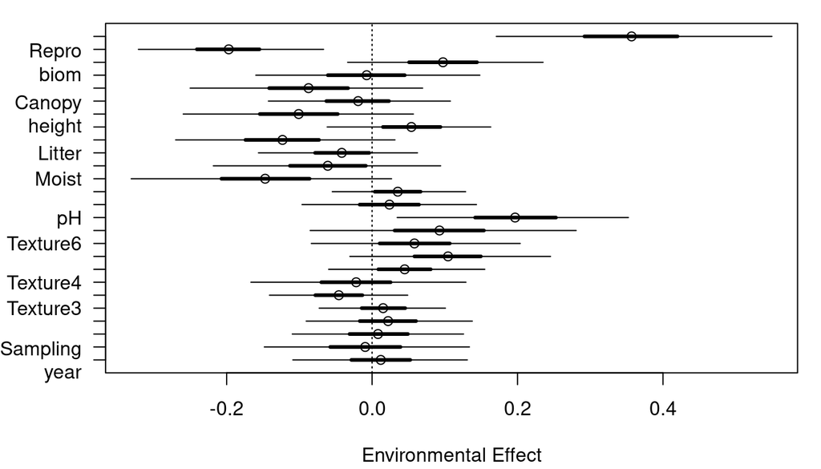

```r
par(mar = c(4.1, 4.5, 1, 1))
PlotPost(var = "B", summ = summ.HO, varnames = gsub("\\.", "\n", colnames(X)),
         xlab = "Environmental Effect", ylab = "")
```

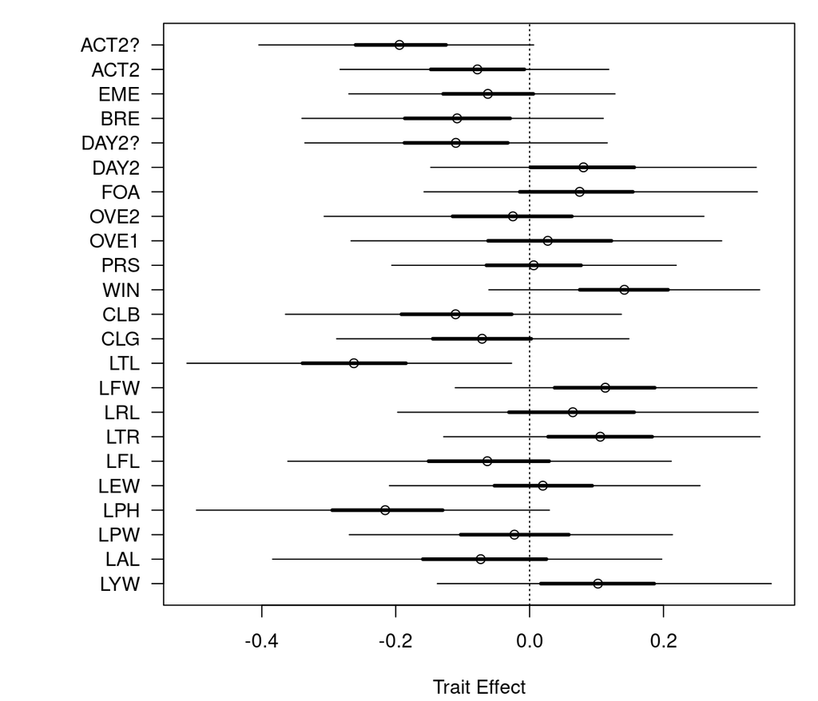

```r
par(mar=c(4.1, 7, 1, 1))
PlotPost(var = "O", summ = summ.HO, varnames = gsub("\\.", "\n", colnames(TR)),
         xlab = "Trait Effect", ylab = "")
```

We can also calculate the full distributions of site and species scores, and plot them. We see that, well, there is variation, so the trait effects are not uncertain because the species scores are uncertain: it is because their effects are small.

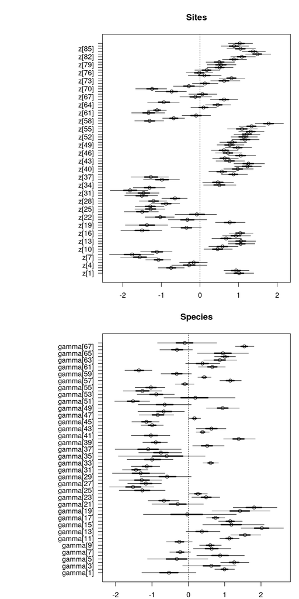

```r
par(mfrow = c(2, 1), mar = c(2, 12, 4, 1))
PlotPost("^z", summ = summ.HO, varnames = NULL, ylab = "", xlab = "Latent variable 1", main = "Sites")
PlotPost("^gamma", summ = summ.HO, varnames = NULL, ylab = "", xlab = "Latent variable 1", main = "Species")
```

## More dimensions

More than one dimension requires adding extra identifiability constraints. Now that we have two or more latent variables, we also have to worry about their rotation.

**For those who are interested, this is how we deal with the rotation**

There are various ways to place the constraints, some more numerically stable than others. Generally, we note that the model on the link scale is similar to existing matrix decompositions, so that much about the required constraints can be learned from those.

**The new model code is included here**

```r
# Model code
# Update our constants from before with the new number of LVs, rest remains the same
# Model code
HO.nim <- nimbleCode({
  for (i in 1:NSites) {
    for (j in 1:NSpecies) {
      eta[i,j] <- beta0[j] + sum(gamma[j,1:nLVs]*sd.LV[1:nLVs]*z[i,1:nLVs])
      log(lambda[i, j]) <- eta[i, j]
      Y[i, j] ~ dnegbin(phi[j]/(phi[j]+lambda[i, j]), phi[j])
    }
    for (l in 1:nLVs) {
      XB[i, l] <- sum(X[i, 1:NEnv]*BSTAR[1:NEnv, l])
      epsilonSTAR[i,l] ~ dnorm(0,sd.Site[l])#Residual
      zSTAR[i,l] <- XB[i,l] + epsilonSTAR[i,l]
    }
  }

  for(j in 1:NSpecies) {
    for (l in 1:nLVs) {
      omegaTR[j, l] <- sum(TR[j, 1:NTraits]*OSTAR[1:NTraits, l])
      varepsilonSTAR[j,l] ~ dnorm(0,sd.Species[l]) # Residual
      gammaSTAR[j,l] <- omegaTR[j,l] + varepsilonSTAR[j,l]
    }

    beta0[j] ~ dnorm(0, sd=1)
  }
  # Constraints to 0 on upper diagonal
  # stole some code from Boral for this - thanks Francis
  for(l in 1:(nLVs-1)) {
    for(ll in (l+1):(nLVs)) {
      BSTAR[l,ll] <- 0
    }
  }


  for(l in 1:nLVs) {
    # diagonal elements
    BSTAR[l,l] ~ dnorm(0,sd=1)

    ## standardizing z and gamma
    zmu[l] <- mean(zSTAR[1:NSites,l])
    StdDev.z[l] <- sqrt(mean((zSTAR[1:NSites,l] - zmu[l])^2))
    z[1:NSites,l] <- (zSTAR[1:NSites,l]-zmu[l])/StdDev.z[l]

    gammamu[l] <- mean(gammaSTAR[1:NSpecies,l])
    StdDev.gamma[l] <- sqrt(mean((gammaSTAR[1:NSpecies,l] - gammamu[l])^2))
    gamma[1:NSpecies,l] <- (gammaSTAR[1:NSpecies,l]-gammamu[l])/StdDev.gamma[l]

  # Scale other parameters
    epsmu[l] <- mean(epsilonSTAR[1:NSites,l])
    varepsmu[l] <- mean(varepsilonSTAR[1:NSpecies,l])

    epsilon[1:NSites,l] <- (epsilonSTAR[1:NSites,l]-epsmu[l])/StdDev.z[l]
    B[1:NEnv,l] <-  BSTAR[1:NEnv,l]/StdDev.z[l]
    varepsilon[1:NSpecies,l] <- (varepsilonSTAR[1:NSpecies,l]-varepsmu[l])/StdDev.gamma[l]
    O[1:NTraits,l] <-  OSTAR[1:NTraits,l]/StdDev.gamma[l]

    # priors for scales
    sd.Site[l] ~ dexp(1)
    sd.Species[l] ~ dexp(1)
    sd.LV[l] ~ dexp(1)
    }

  ## Free lower diagonals
  for(l in 2:nLVs) {
    for(ll in 1:(l-1)) {
      BSTAR[l,ll] ~ dnorm(0,sd=1)
      }
    }
  for(l in (nLVs+1):NEnv) {
    for(ll in 1:(nLVs)) {
      BSTAR[l,ll] ~dnorm(0,1)
    }
  } ## All other elements

  # Prior for trait effects
    for(tr in 1:NTraits){
    for(l in 1:nLVs){
      OSTAR[tr,l] ~dnorm(0,1)
    }
    }
     for(j in 1:NSpecies){
      phi[j] ~ dexp(1)
    }
})
```

**We create a new function to simulate starting values from the prior distributions, which we can hide away**

```r
inits <- function(consts){
    B = matrix(rnorm(consts$nLVs*consts$NEnv),ncol=consts$nLVs)
    B[upper.tri(B)] = 0
    O = matrix(rnorm(consts$nLVs*consts$NTraits),nrow=consts$NTraits)
    varepsilon = mvtnorm::rmvnorm(consts$NSpecies,rep(0,consts$nLVs),diag(consts$nLVs))
    epsilon = mvtnorm::rmvnorm(consts$NSites,rep(0,consts$nLVs),diag(consts$nLVs))
    list(
        BSTAR = B,
        OSTAR = O,
        epsilonSTAR = epsilon,
        varepsilonSTAR = varepsilon,
        sd.Site = rexp(consts$nLVs),
        sd.Species = rexp(consts$nLVs),
        beta0 = rnorm(consts$NSpecies),
        sd.LV = rexp(consts$nLVs),
        phi = runif(consts$NSpecies, 0, 50)
    )
}
```

**We rotate the ordination after the MCMC to make it more interpretable. Here is code to do that, and an explanation of what is done.**

Our model is:

$$\eta_{ij} = \beta_{0j} + \boldsymbol{z}_i^\top \boldsymbol{\Sigma}
\boldsymbol{\gamma}_j.$$

But we can rotate by a rotation matrix $M$ this to get an equivalent model:

$$\eta_{ij} = \beta_{0j} + \boldsymbol{z}_j^\top \boldsymbol{M}
\boldsymbol{\Sigma} \boldsymbol{M}^\top\boldsymbol{\gamma}_i.$$
There are many possible rotations (see the https://cran.r-project.org/web/packages/GPArotation/index.html package for a long list). Here we will just rotate abased on a singular value decomposition (SVD) of the latent variables, as in the *gllvm* *R*-package [Niku *et al.*](https://cran.r-project.org/web/packages/gllvm/index.html). This rotates the ordination so that most of the variation in $\boldsymbol{z}_i^\top \boldsymbol{\Sigma}$ is put on the first latent variable, and so that the second latent variable has the next largest amount of variance. Note, that this does not guarantee that these are the latent variables that explain most variation in the response, unlike in eigenanalysis.

In detail, for each draw from the posterior we:

1. Multiply the LV-specific standard deviations by the column-wise standard deviation of $\boldsymbol{Gamma}$ and/or $\boldsymbol{Z}$ as deemed appropriate
2. Column-wise re-scale $\boldsymbol{B}, \boldsymbol{E}, \boldsymbol{\Gamma}, \boldsymbol{Z}, \boldsymbol{\Omega}$ and $\boldsymbol{\mathcal{E}}$: so that both $\boldsymbol{Z}$ and $\boldsymbol{\Gamma}$ have column-wise unit variance.
3. Calculate a rotation matrix $\boldsymbol{M}$ from $\boldsymbol{Z}\Sigma$
4. Rotate $\boldsymbol{B}, \boldsymbol{E}, \Gamma, \boldsymbol{Z}, \boldsymbol{\Omega}$ and $\boldsymbol{\mathcal{E}}$
5. Column-wise (LV-wise) re-calculate the scale of $\boldsymbol{Z}$, $\boldsymbol{E}$, $\boldsymbol{\mathcal{E}}$

The first step sweeps the scale of the LVs and loadings into the LV-specific scale so it still represents the total variance of the latent variables.

```r
# Function to convert a variable in an MCMC chain that should be a matrix from
# a vector to the right matrix
ChainToMatrix <- function(ch, name) {
  v <- ch[grep(paste0("^", name, "\\["), names(ch))]
  l.row <- as.numeric(gsub(".*\\[", "", gsub(",.*", "", names(v))))
  l.col <- as.numeric(gsub(".*, ", "", gsub("\\]", "", names(v))))
  mat <- matrix(0, nrow=max(l.row), ncol=max(l.col))
  for(i in seq_along(ch)) { # there must be a quicker way...
    mat[l.row[i], l.col[i]] <- v[i]
  }
  mat
}

# Function to convert a variable in an MCMC chain that should be a vector to a diagonal matrix
ChainToDiag <- function(ch, name) {
  v <- ch[grep(paste0("^", name, "\\["), names(ch))]
  mat <- diag(v)
  mat
}

# Function to rotate a latent variable, defaults to Varimax. Methods in GPArotation package
# ch: one draw from MCMC chain
# RotateBy: name of variable to rotate by (i.e. to calculate the rotation matrix for)
# SDby: name of Standard deviations
# ToRotate: Variables to rotate (e.g. epsilons, gamma/z).
# SDToRotate: Standatd devations to rotate
# rotation.fn: Function in GPArotation to calcualte rotation, or svd. Defaults to svd.
# scale: Should RotateBy be scaled by SDby before rotating? Defaults to FALSE
rotate2LV <- function(ch, RotateBy, SDby, ToRotate=NULL, SDToRotate=NULL, rotation.fn="svd",
                      scale=FALSE) {
  require(GPArotation)
  # Function to rotate matrices & return full vector or a matrix (retmat)
  RotateVar <- function(name, vec, rotmat, retmat=FALSE) {
    mat <- ChainToMatrix(ch=vec, name=name)
    rotated <- mat%*%rotmat

    if(retmat) {
      res <- rotated
    } else {
      vec[grep(paste0("^", name, "\\["), names(vec))] <- c(rotated)
      res <- vec
    }
    res
  }
    # Function to rotate (diagonal) matrices & return the diagonal
  RotateSD <- function(name, vec, rotmat) {
    mat <- diag(vec[grep(paste0("^", name, "\\["), names(vec))])
    rotated <- mat%*%rotmat

    vec[grep(paste0("^", name, "\\["), names(vec))] <- diag(rotated)
    vec
  }

  # Extract SDs and latent variables
  SDs <- ch[grep(SDby, names(ch))]
  LVmat <- ChainToMatrix(ch, RotateBy)
  if(scale) LVmat <- sweep(LVmat, 2, SDs, "*")

  # Calculate a rotation matrix
  if(rotation.fn!="svd"){
  loadings.r  <- do.call(rotation.fn, list(A=LVmat)) # rotate
  }else{
  rot <- svd(LVmat)$v
  loadings.r <- list(Th=rot, loadings = LVmat%*%rot)
  }

  # Retrieve correct scale of LVs
  if(scale){
    #also need to put LVs into here
    ch[grep(paste0("^", RotateBy, "\\["), names(ch))]  <- scale(loadings.r$loadings)
    ch[grep(paste0("^", SDby, "\\["), names(ch))] <- attr(scale(loadings.r$loadings),"scaled:scale")
  } else{
   # if LVs are not scaled by LV sds, we just add the new LV scale to LVs SDs.
     ch[grep(paste0("^", RotateBy, "\\["), names(ch))] <- scale(loadings.r$loadings)
     ch[grep(paste0("^", SDby, "\\["), names(ch))] <- attr(scale(loadings.r$loadings),"scaled:scale")*SDs
  }

  # Rotate rest of the variables
  for(nm in unique(ToRotate)) {
    ch <- RotateVar(vec=ch, name=nm, rotmat=loadings.r$Th, retmat = FALSE)
  }
   for(nm in unique(SDToRotate)) {
    ch <- RotateSD(vec=ch, name=nm, rotmat=loadings.r$Th)
  }

  ch
}

RotateChains <- function(mcmc.lst, RotateBy="z", SDby = "sd.LV",
                         ToRotate=c("B", "epsilon", "gamma", "O", "varepsilon"),
                         SDToRotate=c("sd.Site", "sd.Species"), ...) {
  if(SDby%in%SDToRotate)stop("'SDby' should not be present in 'SDToRotate'.")
  if(RotateBy%in%ToRotate)stop("'RotateBy' should not be present in 'ToRotate'.")
  rotated <- lapply(mcmc.lst, function(mcmc) {
    rot <- apply(mcmc, 1, rotate2LV, RotateBy=RotateBy, SDby = SDby,
                         ToRotate=ToRotate, SDToRotate=SDToRotate, ...)
    as.mcmc(t(rot))
  })
  as.mcmc.list(rotated)
}

RescaleVars <- function(vec, ScaleBy, SDTorescale, ToRescale) {
  vec2 <- vec
  ScBy <- ChainToMatrix(vec, ScaleBy)
  SD <- apply(ScBy, 2, sd)

  for(nm in unique(c(ScaleBy, ToRescale))) {
      Sc.x <- ChainToMatrix(vec, nm)
      Sc.x.sc <- sweep(Sc.x, 2, SD, "/")
      vec2[grep(paste0("^", nm, "\\["), names(vec2))] <- c(Sc.x.sc)
  }
  for(nm in SDTorescale) {
    SD.x <- vec[grep(paste0("^", nm, "\\["), names(vec))]
    vec2[grep(paste0("^", nm, "\\["), names(vec2))] <- SD.x*SD
  }
  vec2
}

RescaleChains <- function(mcmc.lst, ...) {
  rescale <- lapply(mcmc.lst, function(mcmc) {
    rot <- apply(mcmc, 1, RescaleVars, ...)
    as.mcmc(t(rot))
  })
  as.mcmc.list(rescale)
}
```

We can run the fitting with the same code as before:

```r
consts$nLVs <- nLVs <- 2
HO.2LV <- ParaNimble(4, fun = RunOneChain,
                       dat = dat,
                       code = HO.nim,
                       inits = inits,
#                       Nburn=5e1, NIter=5.5e2, Nthin=1, # for a small run
                       Nburn = 1e3, NIter = 5e3, Nthin = 1, # for a full run
                       consts = consts,
                       block = MakeBlockList(consts, LVwise=TRUE), RW = c(paste0("beta0[",1:consts$NSpecies,"]"),paste0("phi[",1:consts$NSpecies,"]"))) # HMC on the rest (hypers))

# Re-scale gamma so that its scale is absorbed by LVsd
chains2LV.sc <- RescaleChains(HO.2LV, ScaleBy = "gamma",
                              SDTorescale = c("sd.LV", "sd.Species"),
                              ToRescale = c("gamma",  "O", "varepsilon"))

# Re-scale Z so that its scale is absorbed by LVsd
chains2LV.sc2 <- RescaleChains(chains2LV.sc, ScaleBy = "z",
                              SDTorescale = c("sd.LV", "sd.Site"),
                              ToRescale = c("z",  "B", "epsilon"))

# Now rotate based on Z*Sigma and return its scale as LVsd.
chains2LV.r <- RotateChains(chains2LV.sc2, rotation.fn = "svd", scale = T)
# post-process chains for sign-swapping
chains2LV <- postProcess(chains2LV.r, VarsToProcess = VarsToProcess, VarsToSwapBy = c("1]" = "B[26, 1]", "2]" = "B[22, 2]"), print = F)

# Calculate summaries
summ.HO2LV <- summary(chains2LV)

rm(chains2LV.sc, chains2LV.sc2, chains2LV.r)
```

## Results

**First, we look at the mixing.**

Environment first:

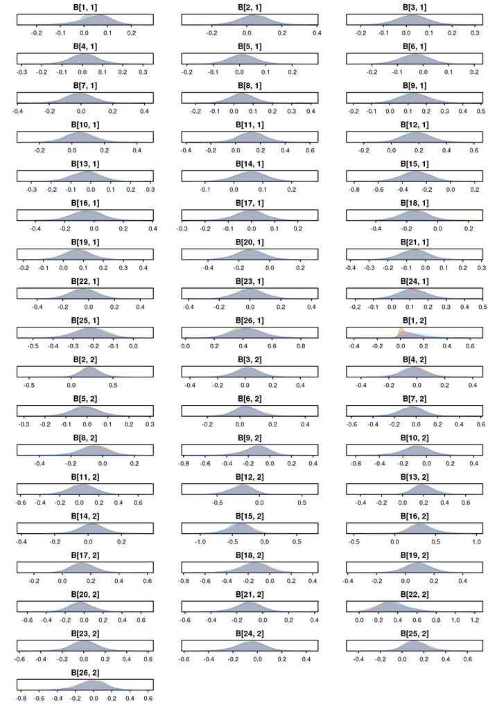

```r
chainsPlot(chains2LV, var = c("B"), legend = F, traceplot=F)
```

And the trait effects:

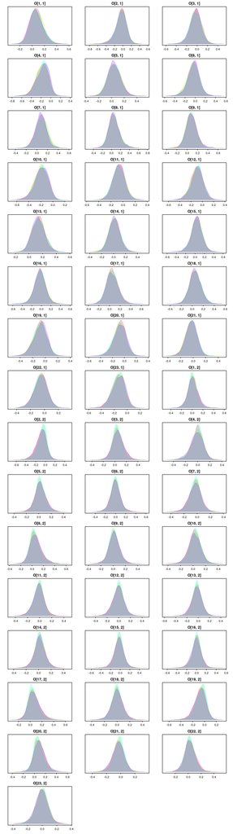

```r
chainsPlot(chains2LV, var = c("O"), legend = F, traceplot=F)
```

```r
Ratio <- chains2LV$chain1[,"sd.LV[1]"]/chains2LV$chain1[,"sd.LV[2]"]
Ratio.u <- HO.2LV$chain1[,"sd.LV[1]"]/HO.2LV$chain1[,"sd.LV[2]"]

SDs <- summ.HO2LV$statistics[grep("sd", rownames(summ.HO2LV$statistic)),]
rownames(SDs) <- c(paste0("Latent Variable ", 1:2),
              paste0("Site ", 1:2),
              paste0("Species ", 1:2))
knitr::kable(SDs, digits=2, format = "html", table.attr = "style='width:70%;'")
```

|  | Mean | SD | Naive SE | Time-series SE |
| --- | --- | --- | --- | --- |
| Latent Variable 1 | 1.83 | 0.10 | 0 | 0.00 |
| Latent Variable 2 | 0.97 | 0.07 | 0 | 0.00 |
| Site 1 | 0.03 | 0.23 | 0 | 0.02 |
| Site 2 | -0.03 | 0.17 | 0 | 0.02 |
| Species 1 | 0.00 | 0.03 | 0 | 0.00 |
| Species 2 | 0.00 | 0.01 | 0 | 0.00 |

What we are really interested in, is looking at the environment-trait interactions. We can plot those with the following code.

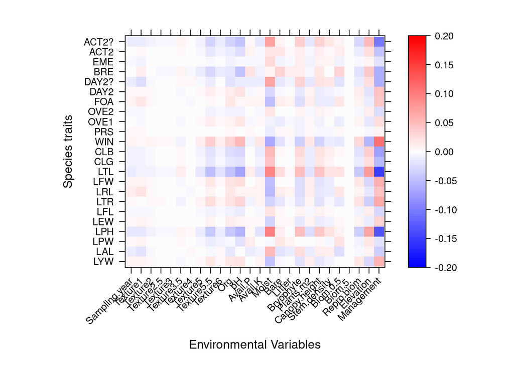

```r
# Function to get MCMC results for reduced-rank approximated interaction term
getMCMCInt <- function(mcmc.lst, dat,...) {
  int.mcmc <- lapply(mcmc.lst, function(mcmc){
    inCoefs <- as.mcmc(t(apply(mcmc, 1, function(ch){
    B <- ChainToMatrix(ch,"B")
    O <- ChainToMatrix(ch,"O")
    SDs <- diag(ch[grep("sd.LV",gsub("\\s*\\[[^\\)]+\\]","",names(ch)))])
    coefs <- B%*%SDs%*%t(O)
    vec <- c(coefs)
    names(vec) <- paste0(colnames(dat$X),":",rep(colnames(dat$TR),each=ncol(dat$X)))
    vec
    })))
  }
  )
  as.mcmc.list(int.mcmc)
}

intChains <- getMCMCInt(chains2LV, dat = dat)
summ.EnvTraitInt <- summary(intChains)
coefs <- matrix(summ.EnvTraitInt$statistics[,1], ncol = ncol(dat$TR), nrow=ncol(dat$X), dimnames = list(colnames(dat$X),colnames(dat$TR)))
a <- 0.2
colort <- colorRampPalette(c("blue", "white", "red"))
lattice::levelplot(coefs, xlab = "Environmental Variables",
                      ylab = "Species traits", col.regions = colort(100), cex.lab = 1.3,
                      at = seq(-a, a, length = 100), scales = list(x = list(rot = 45)))
```

Now, we can make two-dimensional ordination plots of sites and species, with their predictor effects. Note that these have been rotated, so that most ofthe variance should be on the first axis.

**We need a function to plot the arrows, which is hidden here**

```r
AddArrows <- function(coords, marg= par("usr"), col=2) {
  origin <- c(mean(marg[1:2]), mean(marg[3:4]))
  Xlength <- sum(abs(marg[1:2]))/2
  Ylength <- sum(abs(marg[3:4]))/2
  ends <- coords / max(abs(coords)) * min(Xlength, Ylength) * .8
  arrows(
    x0 = origin[1],
    y0 = origin[2],
    x1 = ends[,
              1] + origin[1],
    y1 = ends[, 2] + origin[2],
    col = col,
    length = 0.1)
  text(
    x = origin[1] + ends[, 1] * 1.1,
    y = origin[2] + ends[, 2] * 1.1,
    labels = rownames(coords),
    col = col)

}
```

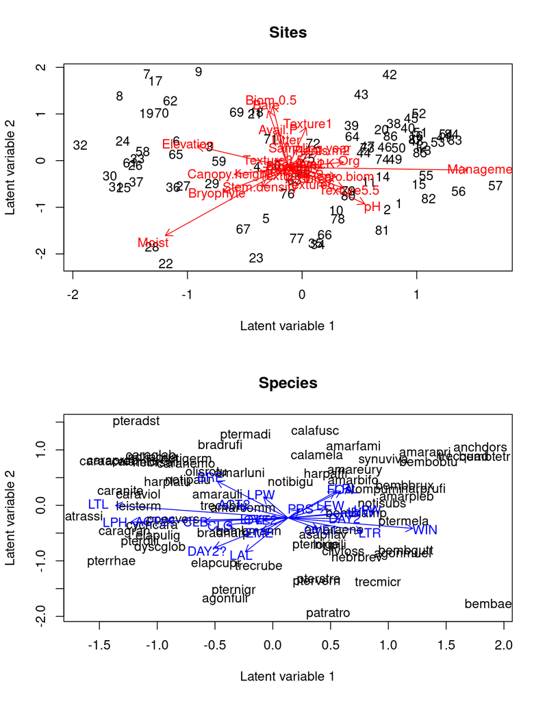

```r
ExtractMeans <- function(mcmc.lst, name=NULL) { # this needs defensive programming
  if(is.null(name)) {
    ind <- 1:nrow(mcmc.lst$statistics)
  } else {
    ind <- grep(name, rownames(mcmc.lst$statistics))
  }
  Means <- mcmc.lst$statistics[ind,"Mean"]
  if(any(grep(",", names(Means)))) {
    Col <- gsub("]", "", unique(gsub(".*, ", "", names(Means))))
    res <- sapply(Col, function(cc, mn) {
      mn[grep(paste0(cc,"]"), names(mn))]
    }, Means)
  } else {
    res <- Means
  }
  res
}
GetMeans <- function(summ, name, d=1) {
  if(is.null(d)) d <- 1
  var <- summ$statistics[grep(paste0('^', name), rownames(summ$statistics)),"Mean"]
  matrix(var,ncol=d)
}


# LVMeans <- ExtractMeans(LVs, name = "^LV\\[")
# gammaMeans <- ExtractMeans(gamma, name="^gamma")

z.m <- GetMeans(summ.HO2LV, name="^z", d=consts$nLVs)
gamma.m <- GetMeans(summ.HO2LV, name="^gamma", d=consts$nLVs)
vareps.m <- GetMeans(summ.HO2LV, name="^varepsilon", d=consts$nLVs)
eps.m <- GetMeans(summ.HO2LV, name="^epsilon", d=consts$nLVs)
B.m <- GetMeans(summ.HO2LV, name="B", d=consts$nLVs)
row.names(B.m) <- colnames(dat$X)
O.m <- GetMeans(summ.HO2LV, name="O", d=consts$nLVs)
row.names(O.m) <- colnames(dat$TR)

par(mfrow=c(2,1))
#LVs
plot(z.m,type="n", xlab="Latent variable 1", ylab="Latent variable 2", main = "Sites")
text(z.m,labels=1:consts$NSites)
AddArrows(marg = par("usr"), coords=B.m, col="red")

#gammas
plot(gamma.m,type="n", xlab="Latent variable 1", ylab="Latent variable 2", main = "Species")
text(gamma.m,labels=vegan::make.cepnames(colnames(Y)))
AddArrows(marg = par("usr"), coords=O.m, col="blue")
```

We can also look at some summary statistics for the scale parameters of the latent variables, species-specific residuals and site-specific residuals, respectively:

These tell us how well the predictors explain the ordination; the species- and site-specific scale parameters would be zero if the predictors fully explained the ordination. The scale parameters for the latent variables are similar to singular values (the square root of eigenvalues) in a classical ordination; they reflect a dimension its importance to the response.

## Residual covariance matrix

The covariance of species is determined by traits, LV-specific variation and sites’ residual variation, and the covariance between sites is determined by the environment, LV-specific variation and species’ residual variation.

**The maths behind this is covered in here**

The residual covariance matrix of the model (where you calculate species associations from) is determined by three terms:

1. $\boldsymbol{X}\boldsymbol{B}\boldsymbol{\Sigma}\boldsymbol{\varepsilon}_j \sim \mathcal{N}(0,\boldsymbol{X}\boldsymbol{B}\boldsymbol{\Sigma}\text{diag}(\boldsymbol{\delta}^2)\boldsymbol{\Sigma}\boldsymbol{B}^\top\boldsymbol{X}^\top)$
2. $\boldsymbol{TR}\boldsymbol{\omega}\boldsymbol{\Sigma}\boldsymbol{\epsilon}_i\sim \mathcal{N}(0,\boldsymbol{T}\boldsymbol{\omega}\boldsymbol{\Sigma}\text{diag}(\boldsymbol{\sigma}^2)\boldsymbol{\Sigma}\boldsymbol{\omega}^\top\boldsymbol{T}^\top)$
3. $\boldsymbol{\epsilon}_i^\top\boldsymbol{\varepsilon}_j \sum \limits^{d}_{q=1}\Sigma_{q,q}\sigma_q\delta_q\sim \mathcal{K}_0(\sigma^{-1}_q\delta^{-1}_q\vert\epsilon_{iq}\varepsilon_{iq}\vert)$,

Consequently, for a species association matrix where we consider the block of the covariance matrix where $i = i2$, or for the site-to-site matrix where we consider the block $j = j2$, we have:

$$\begin{split}
\Sigma_{j,j2} &=
\boldsymbol{x}_i^\top\boldsymbol{B}\boldsymbol{\Sigma}\text{cov}(\boldsymbol{\varepsilon}_j,\boldsymbol{\varepsilon}_{j2})
\boldsymbol{\Sigma}\boldsymbol{B}^\top\boldsymbol{x}_{i} +
\text{cov}(\boldsymbol{\epsilon}_i^\top
\boldsymbol{\Sigma}\boldsymbol{\varepsilon}_j,\boldsymbol{\epsilon}_{i}^\top
\boldsymbol{\Sigma} \boldsymbol{\varepsilon}_{j2}) +
\boldsymbol{tr}_{j}^\top\boldsymbol{\omega}\boldsymbol{\Sigma}\text{var}(\boldsymbol{\epsilon}_{i},\boldsymbol{\epsilon}_{i})\boldsymbol{\Sigma}\boldsymbol{\omega}^\top\boldsymbol{tr}_{j2}
\\
&=
\boldsymbol{x}_i^\top\boldsymbol{B}\boldsymbol{\Sigma}\text{cov}(\boldsymbol{\varepsilon}_j,\boldsymbol{\varepsilon}_{j2})
\boldsymbol{\Sigma}\boldsymbol{B}^\top\boldsymbol{x}_{i} +
\boldsymbol{tr}_{j}^\top\boldsymbol{\omega}\boldsymbol{\Sigma}\text{diag}(\boldsymbol{\sigma}^2)\boldsymbol{\Sigma}\boldsymbol{\omega}^\top\boldsymbol{tr}_{j2}+
2\text{tr}\{\text{diag}(\boldsymbol{\delta}^2)\boldsymbol{\Sigma}\text{diag}(\boldsymbol{\sigma}^2)\boldsymbol{\Sigma}\},
\end{split}$$

and

$$\begin{equation}
\Sigma_{i,i2} =
\boldsymbol{tr}_{j}^\top\boldsymbol{\omega}\boldsymbol{\Sigma}\text{cov}(\boldsymbol{\epsilon}_{i},\boldsymbol{\epsilon}_{i2})\boldsymbol{\Sigma}\boldsymbol{\omega}^\top\boldsymbol{tr}_{j}
+
\boldsymbol{x}_i^\top\boldsymbol{B}\boldsymbol{\Sigma}\text{diag}(\boldsymbol{\delta}^2)\boldsymbol{\Sigma}\boldsymbol{B}^\top\boldsymbol{x}_{i2}
+
2\text{tr}\{\text{diag}(\boldsymbol{\delta}^2)\boldsymbol{\Sigma}\text{diag}(\boldsymbol{\sigma}^2)\boldsymbol{\Sigma}\}.
\end{equation}$$

We can visualize those matrices here for (e.g.,) the first site and first species, respectively.

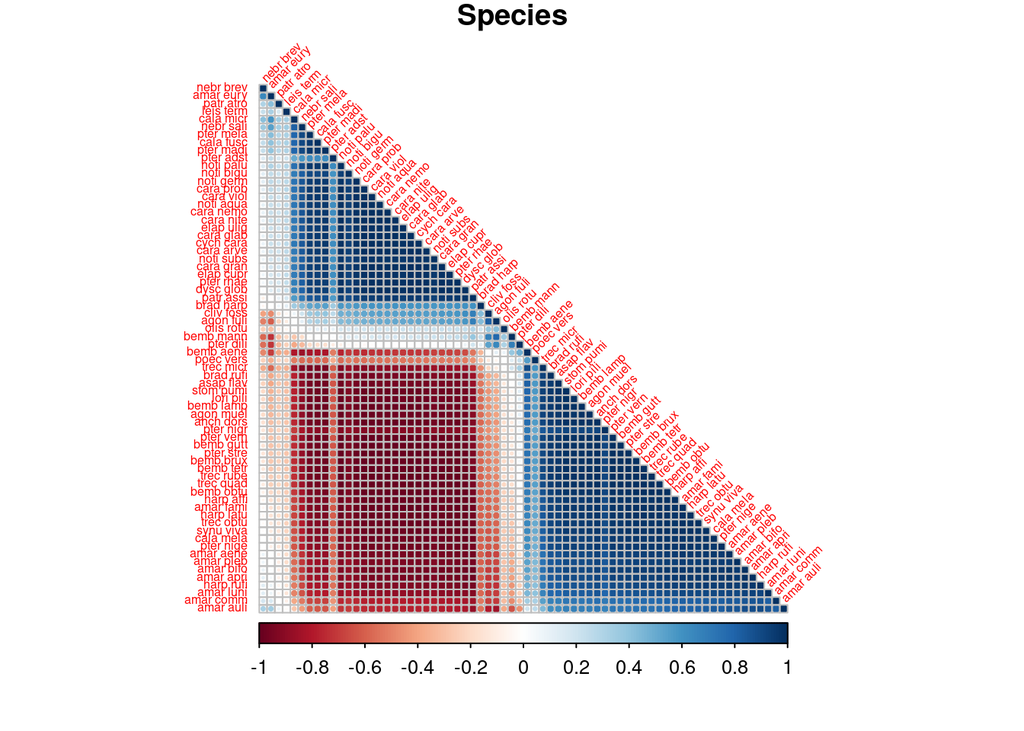

```r
#species
spec.mat <- matrix(0,nrow=consts$NSpecies,ncol=consts$NSpecies)
Sigma <- diag(SDs[grep("Latent Variable", rownames(SDs)),1]^2)
Sigma.sp <- diag(SDs[grep("Species", rownames(SDs)),1]^2)
Sigma.si <- diag(SDs[grep("Site", rownames(SDs)),1]^2)

for(j in 1:consts$NSpecies){
  for(j2 in 1:consts$NSpecies){
    if(j==j2){
      spec.mat[j,j2] = X[1,,drop=F]%*%B.m%*%Sigma%*%Sigma.sp%*%t(B.m)%*%t(X[1,,drop=F])
    }
    spec.mat[j,j2] = spec.mat[j,j2] + TR[j,,drop=F]%*%O.m%*%Sigma%*%Sigma.si%*%Sigma%*%t(O.m)%*%t(TR[j2,,drop=F]) + 2*sum(diag((Sigma.sp%*%Sigma%*%Sigma.si%*%Sigma)))
  }
}

spec.cor.mat <- cov2cor(spec.mat)
colnames(spec.cor.mat) <- row.names(spec.cor.mat) <- colnames(Y)
corrplot::corrplot(spec.cor.mat,type = "lower",order = "AOE", main = "Species", mar = c(1,1,1,1),tl.srt=45,tl.cex = .5)
```

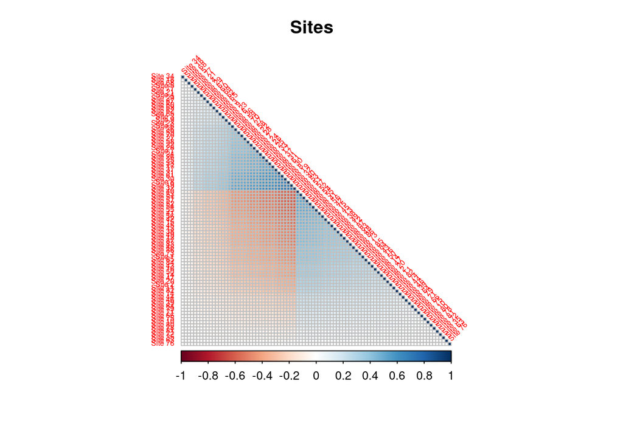

```r
#sites
site.mat <- matrix(0,nrow=consts$NSites,ncol=consts$NSites)

for(i in 1:consts$NSites){
  for(i2 in 1:consts$NSites){
    if(i==i2){
      site.mat[i,i2] = TR[1,,drop=F]%*%O.m%*%Sigma%*%Sigma.si%*%t(O.m)%*%t(TR[1,,drop=F])
    }
    site.mat[i,i2] = site.mat[i,i2] + X[i,,drop=F]%*%B.m%*%Sigma%*%Sigma.sp%*%Sigma%*%t(B.m)%*%t(X[i2,,drop=F]) + 2*sum(diag((Sigma.sp%*%Sigma%*%Sigma.si%*%Sigma)))
  }
}

site.cor.mat <- cov2cor(site.mat)
colnames(site.cor.mat) <- row.names(site.cor.mat) <- paste("Site", 1:consts$NSites)
corrplot::corrplot(site.cor.mat,type = "lower",order = "AOE", main = "Sites", mar = c(3,3,3,3),tl.srt=45,tl.cex = .5)
```